# Statistical Learning - Final Project

As dataset I have chosen “Apple Quality” with the following variables:

- **A_id**: *Unique identifier for each fruit*
- **Size**: *Size of the fruit*
- **Weight**: *Weight of the fruit*
- **Sweetness**: *Degree of sweetness of the fruit*
- **Crunchiness**: *Texture indicating the crunchiness of the fruit*
- **Juiciness**: *Level of juiciness of the fruit*
- **Ripeness**: *Stage of ripeness of the fruit*
- **Acidity**: *Acidity level of the fruit*
- **Quality**: *Overall quality of the fruit*

```r
# Import necessary libraries
library(torch)
library(luz)
library(tidyverse)
library(reshape2)
library(tidyr)
library(dplyr)
library(ggplot2)
library(class)
library(pROC)
# Load the data
data = read.csv("apple_quality.csv")
```

## Preprocessing

As described in the Data Card on Kaggle, the data has already been scaled and cleaned. However, a few preprocessing steps remain. In the code chunk, NA values were removed, the target variable was encoded and converted, and duplicated rows were detected.

```r
set.seed(1)
# Check for total amout of NA
na_counts <- colSums(is.na(data))
print(na_counts)
```

```
       A_id        Size      Weight   Sweetness Crunchiness   Juiciness
          1           1           1           1           1           1
   Ripeness     Acidity     Quality
          1           0           0
```

```r
data <- na.omit(data) # Only one row contains NA, therefore drop

# Encode "bad" = 0 and "good" = 1
data$Quality <- ifelse(data$Quality == "bad", 0,
                ifelse(data$Quality == "good", 1,
                       data$Quality))

# Convert Acidity and Quality (encoded) into numeric
data$Acidity <- as.numeric(data$Acidity)
data$Quality <- as.numeric(data$Quality)

# Check for duplicates
num_duplicates <- sum(duplicated(data))
cat("\n Number of duplicates:", num_duplicates)
```

```
 Number of duplicates: 0
```

Some ML models are affected by outliers. Therefore, outliers were detected visually using boxplots.

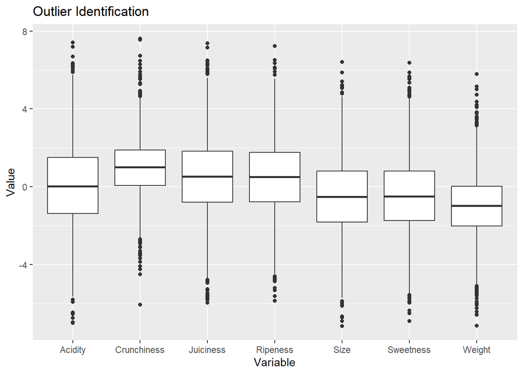

```r
set.seed(1)
# Plot the data for overview and outlier identification
data %>%
  select(-A_id, -Quality) %>%
  pivot_longer(everything(), names_to="Variable", values_to="Value") %>%
  ggplot(aes(x = Variable, y = Value)) +
  geom_boxplot() +
  ggtitle("Outlier Identification")
```

With the filter() function, the outliers were separated from the data (IQR > or < 1.5) and stored in a dataframe. Because there were only 231 outliers in total, I dropped them completely, as the loss of information is minimal.

```r
set.seed(1)
# Move outliers into a seperate dataframe
outliers <- data %>%
  select(A_id, where(is.numeric)) %>%
  pivot_longer(-A_id, names_to="Variable", values_to="Value") %>%
  group_by(Variable) %>%
  # Filter the outliers using the IQR boundries
  filter(Value < quantile(Value, 0.25,na.rm=TRUE) - 1.5
         * IQR(Value, na.rm=TRUE) |
         Value > quantile(Value, 0.75,na.rm=TRUE) + 1.5
         * IQR(Value, na.rm=TRUE)) %>% select(A_id, Variable, Value)

# Print total number of outliers
cat("Number of Outliers:",nrow(outliers))
```

```
Number of Outliers: 231
```

```r
# Drop all outliers
data <- data %>% filter(!A_id %in% outliers$A_id)

# Drop A_id column which is not necessary for analysis
data$A_id <- NULL
```

## Exploratory Analysis

Get summary statistics of the data.

```r
set.seed(1)
# Print data summary
summary(data)
```

```
      Size             Weight            Sweetness        Crunchiness
 Min.   :-5.6921   Min.   :-5.058679   Min.   :-5.5486   Min.   :-2.68386
 1st Qu.:-1.7967   1st Qu.:-1.969178   1st Qu.:-1.7243   1st Qu.: 0.09455
 Median :-0.5147   Median :-0.979754   Median :-0.5057   Median : 0.99691
 Mean   :-0.5114   Mean   :-0.987773   Mean   :-0.4791   Mean   : 0.98522
 3rd Qu.: 0.7692   3rd Qu.: 0.009484   3rd Qu.: 0.7772   3rd Qu.: 1.87462
 Max.   : 4.5248   Max.   : 3.081538   Max.   : 4.6064   Max.   : 4.59194
   Juiciness          Ripeness          Acidity            Quality
 Min.   :-4.7567   Min.   :-4.4712   Min.   :-5.63420   Min.   :0.0000
 1st Qu.:-0.7943   1st Qu.:-0.7077   1st Qu.:-1.37303   1st Qu.:0.0000
 Median : 0.5096   Median : 0.5287   Median : 0.01412   Median :0.0000
 Mean   : 0.4994   Mean   : 0.5290   Mean   : 0.05794   Mean   :0.4913
 3rd Qu.: 1.7865   3rd Qu.: 1.7696   3rd Qu.: 1.46169   3rd Qu.:1.0000
 Max.   : 5.5980   Max.   : 5.5481   Max.   : 5.68525   Max.   :1.0000
```

Output the distribution of the target variable.

```r
set.seed(1)
# Print distribution of target variable
counts <- table(data$Quality)
print(counts)
```

```
   0    1
1928 1862
```

Create histograms of each variable to investigate their distribution.

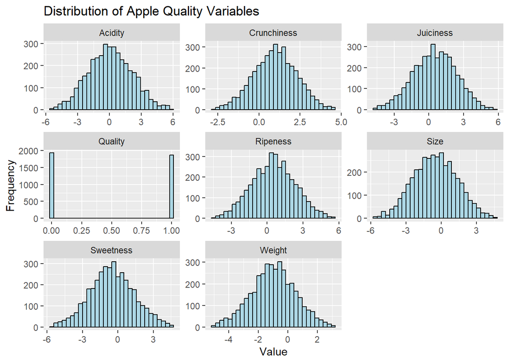

```r
set.seed(1)
# Reshape the dataset into a long format to enable plotting
df_long <- pivot_longer(data,
                        cols = everything(),
                        names_to = "variable",
                        values_to = "value")

# Create histogram
ggplot(df_long, aes(x=value)) +
  geom_histogram(bins=30, fill="lightblue", color="black") +
  facet_wrap(~variable, scales="free") +
  labs(title="Distribution of Apple Quality Variables",
       x="Value",
       y="Frequency")
```

To see how the variables in the dataset influence each other, a correlation matrix was outputted.

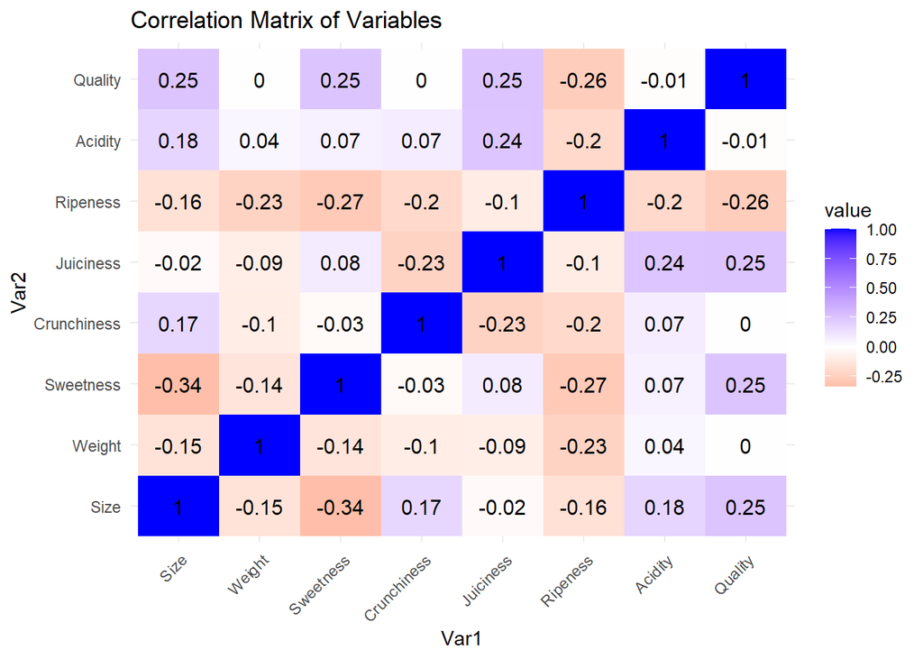

```r
set.seed(1)
# Compute correlation matrix
cor_matrix <- cor(data, use = "complete.obs")

# Convert matrix to long format for ggplot
cor_long <- melt(cor_matrix)

# Plot the correlation matrix
ggplot(cor_long, aes(x = Var1, y = Var2, fill = value)) + geom_tile() +
  geom_text(aes(label = round(value, 2)), color = "black", size = 4) +
  scale_fill_gradient2(low = "red", mid = "white", high = "blue") +
  labs(title = "Correlation Matrix of Variables") +
  theme_minimal() +
  theme(axis.text.x = element_text(angle = 45, hjust = 1))
```

## Train-Validation-Test Split

The dataset was split into training, validation, and test sets with a proportion of approximately 60-20-20.

```r
set.seed(1)
# Apply Test-Validation-Train split on dataset (n = 3.790)
# ~ 20% Test set (n = 790)
train <- sample(1:nrow(data), 3000)
df_train_ov <- data[train,]
df_test <- data[-train,]

# 20% Validation set (n = 800)
val <- sample(1:nrow(df_train_ov), 800)
df_val <- df_train_ov[val,]

# 60% Train set (n = 2.200)
df_train <- df_train_ov[-val,]
```

And directly converted to torch_tensor for later usage.

```r
# Convert predictor and target variables of sets to tensors
x_train_tensor <- torch_tensor(as.matrix(df_train %>% select(-Quality)),
                                  dtype=torch_float())

y_train_tensor <- torch_tensor(as.matrix(df_train$Quality),
                               dtype=torch_float())

x_val_tensor <- torch_tensor(as.matrix(df_val %>% select(-Quality)),
                                  dtype=torch_float())

y_val_tensor <- torch_tensor(as.matrix(df_val$Quality),
                               dtype=torch_float())

x_test_tensor <- torch_tensor(as.matrix(df_test %>% select(-Quality)),
                              dtype = torch_float())

y_test_tensor <- torch_tensor(as.matrix(df_test$Quality),
                              dtype=torch_float())
```

Additionally, a dataloader was created to handle batch size transitions.

```r
# Define dataloader
train_ds <- tensor_dataset(x_train_tensor, y_train_tensor)
train_dl <- dataloader(train_ds, batch_size = 32, shuffle = FALSE)

val_ds <- tensor_dataset(x_val_tensor, y_val_tensor)
val_dl <- dataloader(val_ds, batch_size = 32, shuffle = FALSE)

test_ds <- tensor_dataset(x_test_tensor, y_test_tensor)
test_dl <- dataloader(test_ds, batch_size = 32, shuffle = FALSE)
```

## Task 1 - Deep Feedforward Neural Network

Use Keras/Torch to construct a deep feedforward neural network (excluding convolutional and recurrent layers) with a minimum of three hidden layers to predict either a category (classification) or a continuous value (regression).

Ensure that your neural network:

• Has properly cleaned data (e.g., one-hot encoding, removal of symbols like dollar signs, handling missing values).

• Uses scaled or normalized data (e.g., Z-score standardization) before training.

• Has a suitable architecture and loss function for the problem.

• Reports at least two evaluation metrics for both training and test data.

First, the Deep Neural Network was defined using the torch library. The model consists of fully connected layers with ReLU activation functions, dropout, and a final sigmoid activation for binary classification (only concepts learned in the lecture were used). Second, the network was configured with binary cross-entropy loss, the Adam optimizer (Stochastic Gradient), and the two evaluation metrics accuracy and AUC. Learning Rate and L2-Regularization where configured manually. = More details in report.

```r
set.seed(1)
# Define Neural Network using torch
deep_nn <- nn_module(
  "Deep_Neural_Network",
  initialize = function() {
    self$fc1 = nn_linear(7, 128)  # Input to Hidden1
    self$drop1 = nn_dropout(0.4)  # Dropout 0.4

    self$fc2 = nn_linear(128, 64)  # Hidden1 to Hidden2
    self$drop2 = nn_dropout(0.3)

    self$fc3 = nn_linear(64, 32)  # Hidden2 to Hidden3
    self$drop3 = nn_dropout(0.2)

    self$fc4 = nn_linear(32, 16)  # Hidden3 to Hidden4
    self$drop4 = nn_dropout(0.1)

    self$fc5 = nn_linear(16, 1)  # Hidden4 to Output
  },

  # Forward pass
  forward = function(x) {
    x %>%
      self$fc1() %>% torch_relu() %>% self$drop1() %>% # Apply ReLU
      self$fc2() %>% torch_relu() %>% self$drop2() %>%
      self$fc3() %>% torch_relu() %>% self$drop3() %>%
      self$fc4() %>% torch_relu() %>% self$drop4() %>%
      self$fc5() %>% torch_sigmoid() # Sigmoid for binary classification
  }
)

# Configure the NN for training
deep_nn <- deep_nn %>%
  setup(
    loss = nn_bce_loss(), #Binary BCS Loss for binary classification
    optimizer = optim_adam, #Adam (Stochastic Gradient Descent)
    metrics = list(
      luz_metric_binary_accuracy(), # Binary Classification Accuracy
      luz_metric_binary_auroc() # Binary AUC
    )
  ) %>%
  # Setting learning rate and L2-Reg manually
  set_opt_hparams(lr = 0.001, weight_decay = 0.001)
```

After the configuration, the model needs to be trained. To evaluate the model on different subsets of the data, 10-fold cross-validation is used. First, df_train_ov (excluding df_test but including df_val) is resampled to create 10 folds, where the model is trained on 9 folds and the remaining fold is used as the validation set. Metrics for both the training and validation process are stored and printed afterward. The model is trained for 100 epochs, but training stops early if the early stopping criterion is met. Metrics were manually tuned.

= At the beginning the model was manually tuned (see report)

```r
set.seed(1)
# Number of folds
k_folds <- 10

# Create k-fold CV splits using resample
folds <- rsample::vfold_cv(data.frame(df_train_ov), v = k_folds)

# Initialize vectors for data storage
val_loss <- numeric(k_folds)
train_acc <- numeric(k_folds)
val_acc <- numeric(k_folds)
train_aucs <- numeric(k_folds)
val_aucs <- numeric(k_folds)

# Save best model based on AUC
best_model <- NULL
best_val_auc <- -Inf # -Inf ensures that any AUC is better

# Loop through each fold
for (i in seq_along(folds$splits)) {
  cat("Training Fold", i, "\n")

  # Get train and val indicies for current fold
  train_idx <- rsample::analysis(folds$splits[[i]])
  val_idx <- rsample::assessment(folds$splits[[i]])

  # Convert predictor and target variables to torch tensors
  x_train_tensor_fold <- torch_tensor(as.matrix(
    train_idx %>% select(-Quality)), dtype=torch_float())

  x_val_tensor_fold <- torch_tensor(as.matrix(
    val_idx %>% select(-Quality)), dtype=torch_float())

  y_train_tensor_fold <- torch_tensor(as.matrix(train_idx$Quality),
                                 dtype=torch_float())

  y_val_tensor_fold <- torch_tensor(as.matrix(val_idx$Quality),
                               dtype=torch_float())

  # Create dataset and dataloader
  train_ds_cv <- tensor_dataset(x_train_tensor_fold, y_train_tensor_fold)
  train_dl_cv <- dataloader(train_ds_cv, batch_size = 32, shuffle = TRUE)

  val_ds_cv <- tensor_dataset(x_val_tensor_fold, y_val_tensor_fold)
  val_dl_cv <- dataloader(val_ds_cv, batch_size = 32, shuffle = FALSE)

  # Train the Deep NN
  fitted <- deep_nn %>%
    fit(
      data = train_dl_cv,
      epochs = 100, # Train on 100 epochs
      valid_data = val_dl_cv, # On validation data
      verbose = FALSE,
      callbacks = list(
        luz_callback_early_stopping( # Early Stopping to prevent OF
          monitor = "valid_loss",
          min_delta = 0.001, # Minimum required improvement
          patience = 10 # Stop if no improvement for 10 epochs
        )
      )
    )

  # Save training and validation metrics
  df_metrics <- get_metrics(fitted)

  # Extract Loss,Accuracies and AUCs
  val_loss[[i]] <- df_metrics %>%
    filter(set == "valid", metric == "loss") %>%
    tail(1) %>%
    pull(value) %>% as.numeric()

  train_acc[i] <- df_metrics %>%
    filter(set == "train", metric == "acc") %>%
    tail(1) %>%
    pull(value)

  val_acc[i] <- df_metrics %>%
    filter(set == "valid", metric == "acc") %>%
    tail(1) %>%
    pull(value)

  train_aucs[i] <- df_metrics %>%
    filter(set == "train", metric == "auc") %>%
    tail(1) %>%
    pull(value)

  val_aucs[i] <- df_metrics %>%
    filter(set == "valid", metric == "auc") %>%
    tail(1) %>%
    pull(value)

  # Update best model selection
  if (val_aucs[[i]] > best_val_auc) {
    best_val_auc <- val_aucs[[i]]
    best_model <- fitted
  }
}
```

```
Training Fold 1
Training Fold 2
Training Fold 3
Training Fold 4
Training Fold 5
Training Fold 6
Training Fold 7
Training Fold 8
Training Fold 9
Training Fold 10
```

```r
# Comppute mean of all model metrics
cv_mean_loss <- mean(val_loss)
cv_mean_train_acc <- mean(train_acc)
cv_mean_train_auc <- mean(train_aucs)
cv_mean_val_acc <- mean(val_acc)
cv_mean_val_auc <- mean(val_aucs)

# Print metrics
print(paste("Mean Validation Loss:", cv_mean_loss))
```

```
[1] "Mean Validation Loss: 0.163187403231859"
```

```r
print(paste("Mean Training Accuracy:", cv_mean_train_acc))
```

```
[1] "Mean Training Accuracy: 0.939148148148148"
```

```r
print(paste("Mean Training AUC:", cv_mean_train_auc))
```

```
[1] "Mean Training AUC: 0.982005125284195"
```

```r
print(paste("Mean Validation Accuracy:", cv_mean_val_acc))
```

```
[1] "Mean Validation Accuracy: 0.944666666666667"
```

```r
print(paste("Mean Validation AUC:", cv_mean_val_auc))
```

```
[1] "Mean Validation AUC: 0.983436220884323"
```

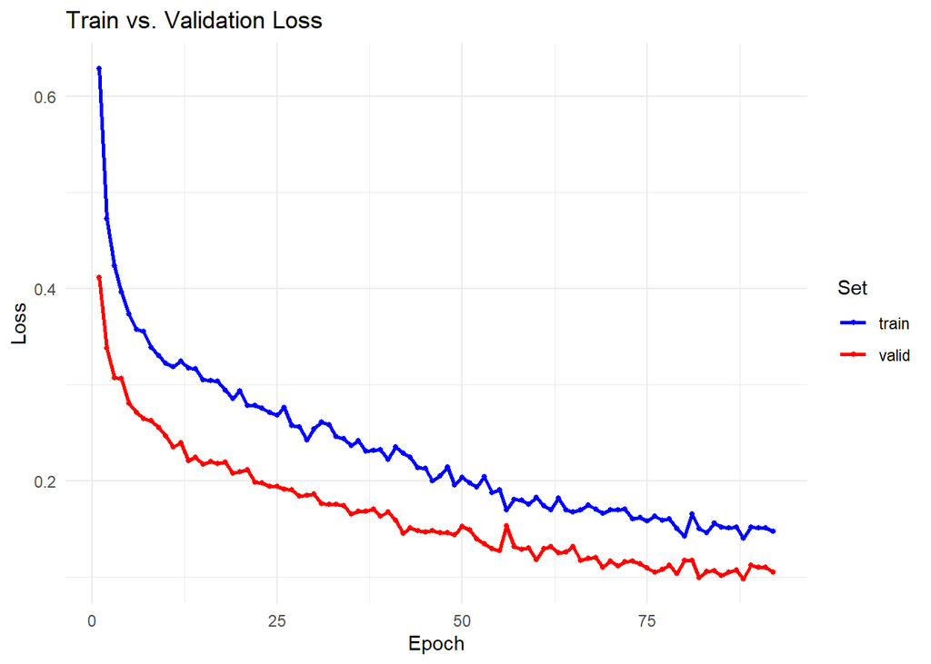

```r
set.seed(1)
# Save metrics of best model
df_metrics <- get_metrics(best_model)

# Loss-Plot
ggplot(df_metrics %>% filter(metric == "loss"), aes(x = epoch, y = value, color = set)) +
  geom_line(size = 1) +
  geom_point(size = 1) +
  labs(title = "Train vs. Validation Loss", y = "Loss", x = "Epoch") +
  theme_minimal() +
  scale_color_manual(name = "Set", values = c("train" = "blue", "valid" = "red"))
```

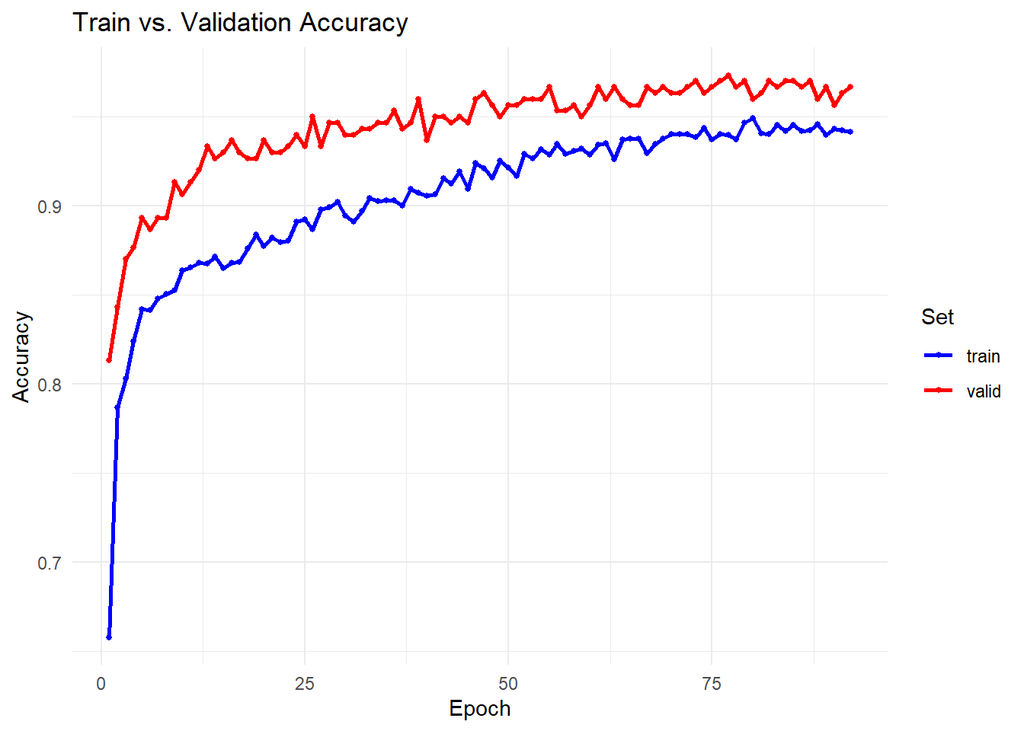

```r
# Accuracy-Plot
ggplot(df_metrics %>% filter(metric == "acc"), aes(x = epoch, y = value, color = set)) +
  geom_line(size = 1) +
  geom_point(size = 1) +
  labs(title = "Train vs. Validation Accuracy", y = "Accuracy", x = "Epoch") +
  theme_minimal() +
  scale_color_manual(name = "Set", values = c("train" = "blue", "valid" = "red"))
```

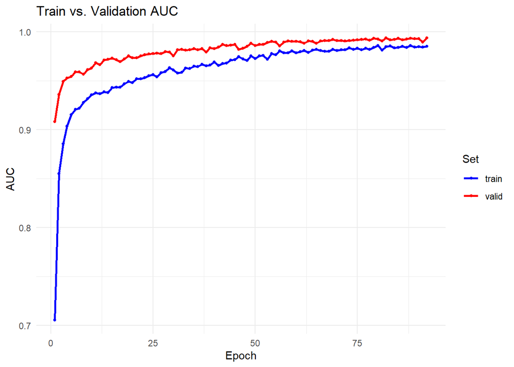

```r
# AUC-Plot
ggplot(df_metrics %>% filter(metric == "auc"), aes(x = epoch, y = value, color = set)) +
  geom_line(size = 1) +
  geom_point(size = 1) +
  labs(title = "Train vs. Validation AUC", y = "AUC", x = "Epoch") +
  theme_minimal() +
  scale_color_manual(name = "Set", values = c("train" = "blue", "valid" = "red"))
```

The best model is applied on the test data (results are shown in evaluation part).

```r
set.seed(1)
# Apply best model on test set
true_test_best <- y_test_tensor %>% as_array() %>% as.numeric()
pred_test_best <- best_model %>% predict(test_dl) %>% as_array
```

## Task 2 - K-nearest-neighbor

To determine whether a neural network was necessary, build a simpler statistical learning model from this course and compare the performance. Make sure to use the same predictors and outcome.

Choose one of these models and compare the performance against your neural network to justify and convince me whether deep learning was necessary for the task or not.

For this analysis, df_train_ov was used for tuning, representing the training data with n = 3000. The data has been separated into predictor and target sets, and the target sets has been factorized.

```r
set.seed(1)
# Create seperate dataset for target and predictor variables
x_train <- df_train_ov[, -which(names(df_train_ov) == "Quality")]
y_train <- as.factor(df_train_ov$Quality) # factorize target

x_test <- df_test[, -which(names(df_test) == "Quality")]
y_test <- as.factor(df_test$Quality)
```

To determine the best k (from 1 to 20) for the KNN classifier, Leave-One-Out–Cross-Validation (LOOCV) was applied to the training and validation data. In LOOCV, the model is trained on n-1 samples, making it suitable for small datasets. Although the dataset is not small, the code runs efficiently. The k value with the lowest LOOCV error was selected, which is visualized in the plot at k = 10.

```r
set.seed(1)

n <- nrow(x_train) # Get total number of observations
k_values <- 1:20 # Define range of k values
loocv_errors <- numeric(length(k_values)) # Empty vector for results

# Loop through each k value to compute LOOCV errors
for (i in seq_along(k_values)) {
  k <- k_values[i]
  errors <- 0 # Initialize error counter

  # Perform LOOCV
  for (j in 1:n) {
    # Define training and validation sets
    train_X_loocv <- x_train[-j, , drop = FALSE] # excluding j
    val_X_loocv <- x_train[j, , drop = FALSE] # including j
    train_Y_loocv <- y_train[-j]
    val_Y_loocv <- y_train[j]

    # Apply KNN
    pred <- knn(train_X_loocv, val_X_loocv, train_Y_loocv, k = k)

    # Count missclassifications
    if (pred != val_Y_loocv) {
      errors <- errors + 1
    }
  }
  # Compute LOOCV error rate
  loocv_errors[i] <- errors / n
}

# Select best k (that minimizes LOOCV error)
best_k <- k_values[which.min(loocv_errors)]

cat("Best k:", best_k, "\n")
```

```
Best k: 10
```

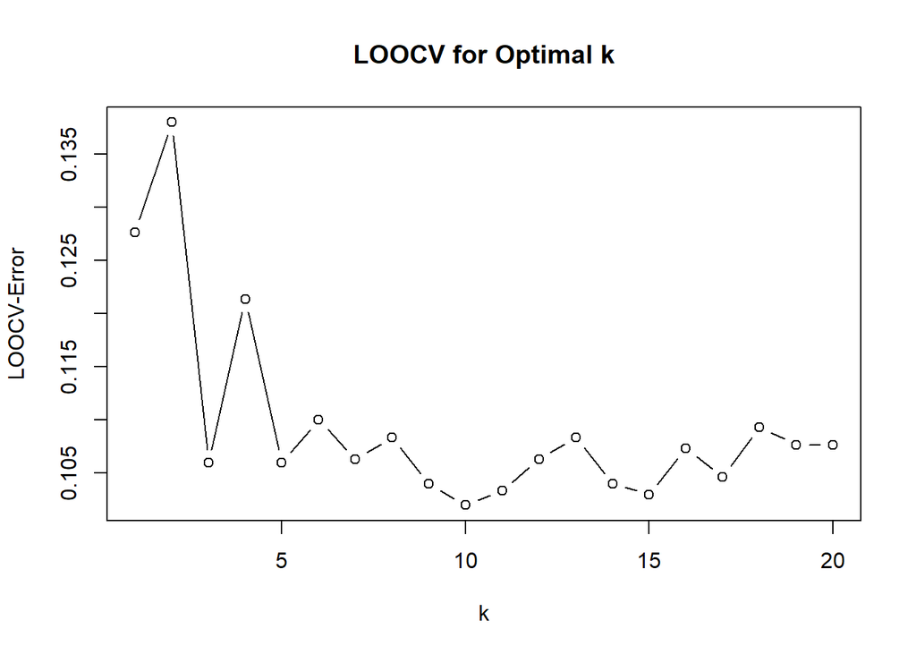

```r
# Plot LOOCV errors for different k values
plot(k_values,
     loocv_errors,
     type = "b",
     xlab = "k",
     ylab = "LOOCV-Error",
     main = "LOOCV for Optimal k")
```

Fit model with best k on test set.

```r
set.seed(1)
# Apply best k on test set
pred_test <- knn(x_train, x_test, y_train, k = best_k)
```

## Evaluation

First, evaluation metrics for accuracy, precision, recall, and F1-score were defined as functions to reuse them.

```r
set.seed(1)
# Function to calculate accuracy
accuracy <- function(true, pred) {
  acc <- (mean(true == pred))
  return (round(acc, 4)*100)
  }

# Function to calculate precision
precision <- function(conf_matrix) {
  TP <- conf_matrix[2, 2]  # True Positives
  FP <- conf_matrix[1, 2]  # False Positives

  precision <- TP / (TP + FP)
  return (round(precision, 4)*100)
}

# Function to calculate recall
recall <- function(conf_matrix) {
  TP <- conf_matrix[2, 2]  # True Positives
  FN <- conf_matrix[2, 1]  # False Negatives

  recall <- TP / (TP + FN)
  return (round(recall, 4)*100)
}

# Function to calculate F1-score
f1 <- function(conf_matrix) {
  prec <- precision(conf_matrix)
  rec <- recall(conf_matrix)

  f1_score <- 2 * (prec * rec) / (prec + rec)
  return (round(f1_score, 2))
}
```

Another function for plotting the ROC-Curve and Calculation AUC was created.

```r
set.seed(1)
# Function to plot ROC curve and calculates AUC for specific model
plot_roc_curve <- function(true, pred_prob, model) {
  # Convert to numeric
  pred_prob <- as.numeric(as.character(pred_prob))
  # Compute ROC curve object
  roc_obj <- roc(true, pred_prob)
  # Compute AUC (Area under Curve of ROC)
  auc_value <- auc(roc_obj)

  # Create df to plot ROC curve
  roc_df <- data.frame(
    FPR = 1 - roc_obj$specificities,
    TPR = roc_obj$sensitivities)

  # Plot ROC Curve
  ggplot(roc_df, aes(x = FPR, y = TPR)) +
    geom_line(color = "blue", size = 1) +
    geom_abline(linetype = "dashed", color = "gray") +
    labs(title = paste("ROC Curve -", model),
         x = "False Positive Rate",
         y = "True Positive Rate",
         subtitle = paste("AUC =", round(auc_value, 4))) +
    theme_minimal()
}
```

And another function to visualize a (prettier) confusion matrix.

```r
set.seed(1)
# Function to compute and plot confusion matrix
confusion_matrix <- function(true, pred, model) {
  # Create confusion matrix
  pred <- as.numeric(as.character(pred))
  pred_class <- ifelse(pred > 0.5, 1, 0)
  conf_matrix <- table(true, pred_class)

  # Convert to df
  conf_df <- as.data.frame(conf_matrix)
  colnames(conf_df) <- c("Actual", "Predicted", "Count")

  # Plot Confusion Matrix
  ggplot(conf_df, aes(x = Predicted, y = Actual, fill = Count)) +
    geom_tile() +
    geom_text(aes(label = Count)) +
    scale_fill_gradient(low = "lightblue", high = "blue") +
    labs(title = paste("Confusion Matrix:", model),
       x = "Predicted",
       y = "Actual") + theme_minimal()
}
```

Finally, all metrics were summarized in a plot_metrics() function to evaluate a classifier.

```r
set.seed(1)
# Function to plot all above named metrics at once
plot_metrics <- function(true, pred, model) {
  pred <- as.numeric(as.character(pred))
  pred_class <- ifelse(pred > 0.5, 1, 0)
  conf_matrix <- table(true, pred_class)

  if (model == "KNN") {
    cat("Error Rate: ", 100 - accuracy(true, pred_class), "% \n")
  }
  cat("Accuracy: ", accuracy(true, pred_class), "% \n")
  cat("Precision:", precision(conf_matrix), "% \n")
  cat("Recall:", recall(conf_matrix), "% \n")
  cat("F1-Score:", f1(conf_matrix), "% \n")
}
```

## Evaluation - Deep NN

In this section the evaluation of the Deep Neural Network happens. First the general parameter information is printed.

```r
set.seed(1)
# Print architecture of the NN
print(deep_nn())
```

```
An `nn_module` containing 11,905 parameters.

── Modules ─────────────────────────────────────────────────────────────────────
• fc1: <nn_linear> #1,024 parameters
• drop1: <nn_dropout> #0 parameters
• fc2: <nn_linear> #8,256 parameters
• drop2: <nn_dropout> #0 parameters
• fc3: <nn_linear> #2,080 parameters
• drop3: <nn_dropout> #0 parameters
• fc4: <nn_linear> #528 parameters
• drop4: <nn_dropout> #0 parameters
• fc5: <nn_linear> #17 parameters
```

Followed by the plot_metrics() function to get Accuracy, Precision, Recall and F1-Score

```r
set.seed(1)
# Deep NN metrics for test data
plot_metrics(true_test_best, pred_test_best, "Deep NN")
```

```
Accuracy:  95.7 %
Precision: 94.28 %
Recall: 97.18 %
F1-Score: 95.71 %
```

Plot confusion matrix.

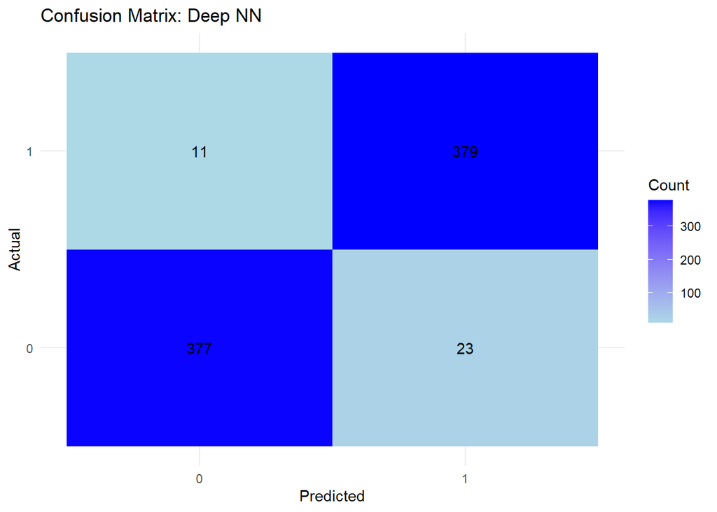

```r
set.seed(1)
# Plot (prettier) confusion matrix
confusion_matrix(true_test_best, pred_test_best, "Deep NN")
```

Plot ROC curve and AUC

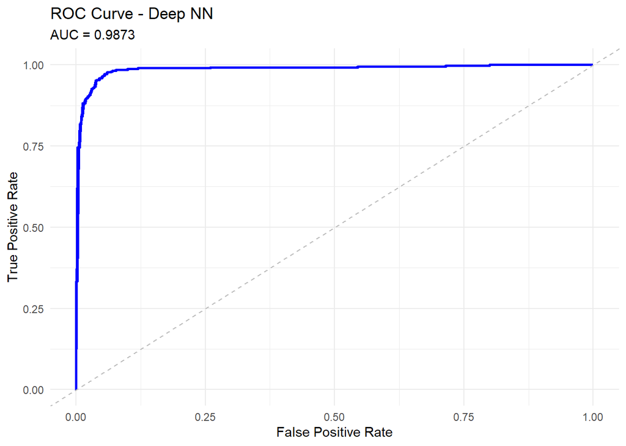

```r
set.seed(1)
# Plot ROC curve and AUC
plot_roc_curve(true_test_best, pred_test_best, "Deep NN")
```

```r
set.seed(1)
iterations <- 1000
accuracy_nn <- numeric(iterations)
precision_nn <- numeric(iterations)
recall_nn <- numeric(iterations)

# Loop for bootstrap iterations
for (i in 1:iterations) {
  # Create a bootstrap sample from the test set
  boot_indices <- sample(1:nrow(x_test), size = 800, replace = TRUE)
  x_test_boot <- x_test[boot_indices, ]
  y_test_boot <- y_test[boot_indices]

  # Convert to tensors
  x_test_tensor_boot <- torch_tensor(as.matrix(x_test_boot),
                                     dtype = torch_float())
  y_test_tensor_boot <- torch_tensor(as.numeric(y_test_boot),
                                     dtype = torch_float())

  # Define dataloader
  test_ds_boot <- tensor_dataset(x_test_tensor_boot, y_test_tensor_boot)
  test_dl_boot <- dataloader(test_ds_boot, batch_size=32, shuffle=FALSE)

  # Make predictions using pre-trained model
  pred_boot_test <- best_model %>% predict(test_dl_boot) %>% as_array()
  pred_boot_test <- as.numeric(pred_boot_test > 0.5)

  # Create confusion matrix
  conf_matrix <- table(y_test_boot, pred_boot_test)

  # Compute metrics
  accuracy_nn[i] <- accuracy(y_test_boot, pred_boot_test)
  recall_nn[i] <- recall(conf_matrix)
  precision_nn[i] <- precision(conf_matrix)
}

# Compute 95% confidence intervals
cat("NN Accuracy CI: ", quantile(accuracy_nn, c(0.025, 0.975)), "\n")
```

```
NN Accuracy CI:  94.25 97
```

```r
cat("NN Recall CI: ", quantile(recall_nn, c(0.025, 0.975)), "\n")
```

```
NN Recall CI:  95.44975 98.73
```

```r
cat("NN Precision CI: ", quantile(precision_nn, c(0.025, 0.975)), "\n")
```

```
NN Precision CI:  92.04 96.39
```

Combine the metrics in a dataframe to plot them as boxplots and density plots.

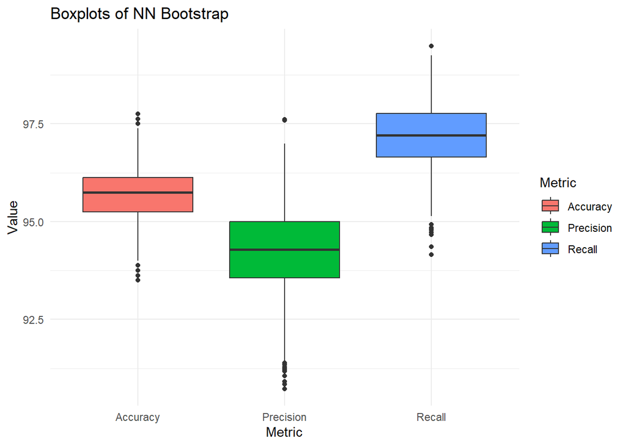

```r
set.seed(1)
# Combine results into a dataframe
results_nn <- data.frame(
  Metric = rep(c("Accuracy", "Recall", "Precision"), each = iterations),
  Value = c(accuracy_nn, recall_nn, precision_nn))

# Boxplot
ggplot(results_nn, aes(x = Metric, y = Value, fill = Metric)) +
  geom_boxplot() +
  labs(title = "Boxplots of NN Bootstrap",
       y = "Value") +
  theme_minimal()
```

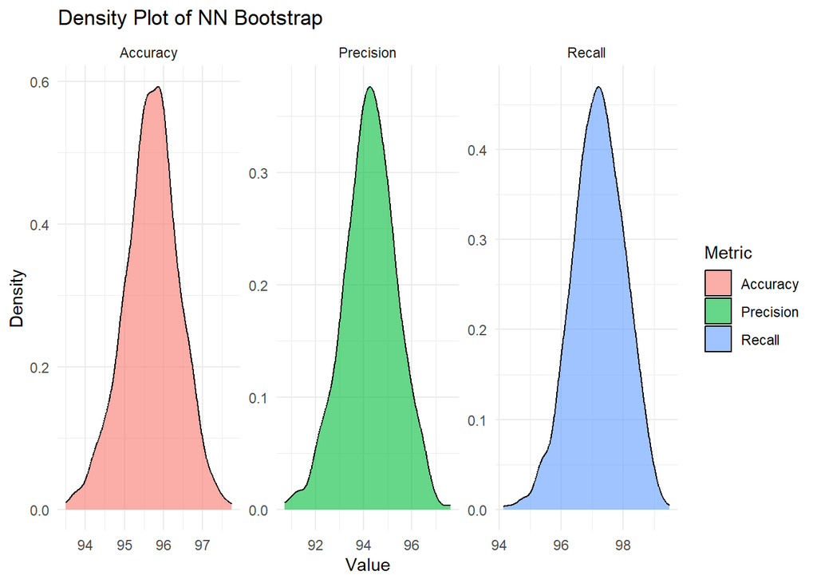

```r
# Density Plot
ggplot(results_nn, aes(x = Value, fill = Metric)) +
  geom_density(alpha = 0.6) +
  facet_wrap(~Metric, scales = "free") +
  labs(title = "Density Plot of NN Bootstrap",
       x = "Value",
       y = "Density") +
  theme_minimal()
```

## Evaluation - KNN

In this section the evaluation of the KNN happens. First the plot_metrics() function provides Test-Error-Rate, Accuracy, Precision, Recall and F1-Score.

```r
set.seed(1)
# KNN metrics for test data
plot_metrics(y_test, pred_test, "KNN")
```

```
Error Rate:  13.04 %
Accuracy:  86.96 %
Precision: 86.51 %
Recall: 87.18 %
F1-Score: 86.84 %
```

Plot confusion matrix.

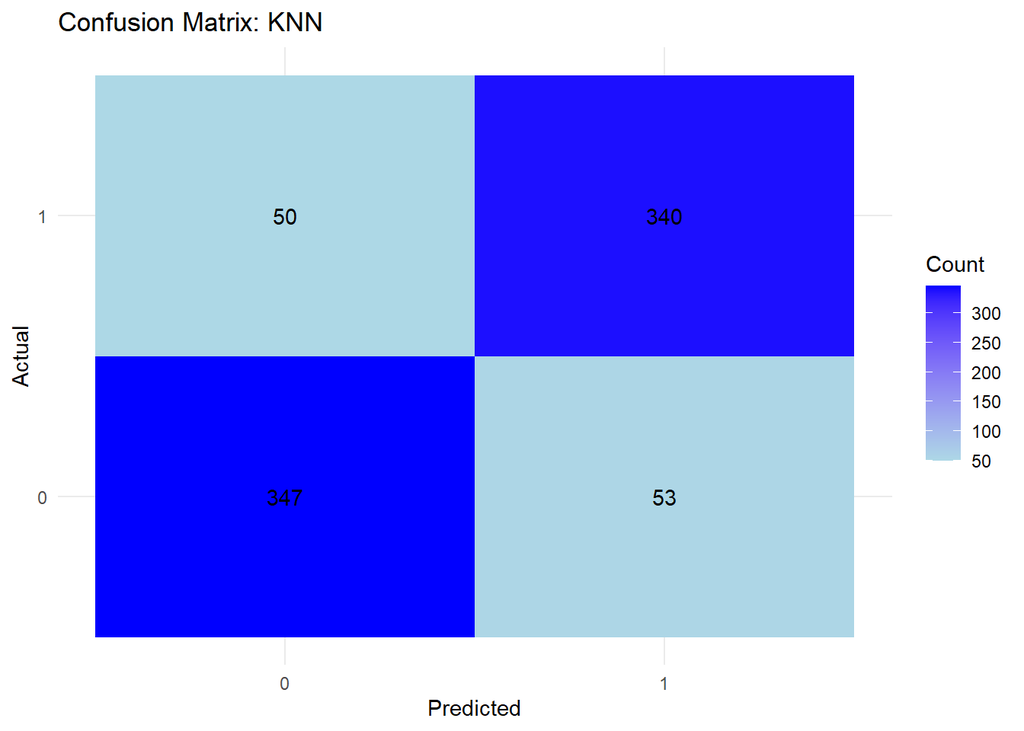

```r
set.seed(1)
# Plot (prettier) confusion matrix
confusion_matrix(y_test, pred_test, "KNN")
```

Plot ROC curve and AUC.

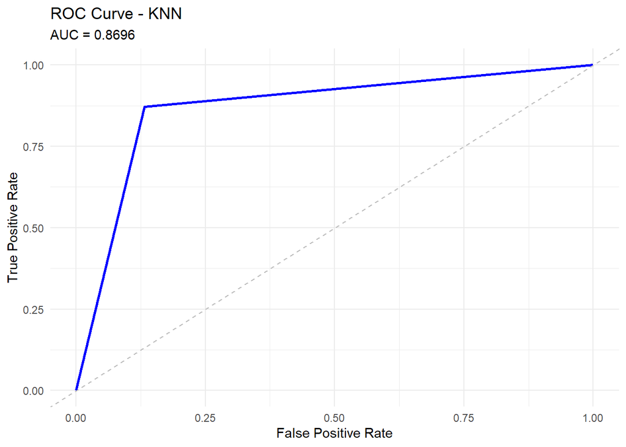

```r
set.seed(1)
# Plot ROC curve and AUC
plot_roc_curve(y_test, pred_test, "KNN")
```

```r
set.seed(1)
iterations <- 1000
accuracy_knn <- numeric(iterations)
recall_knn <- numeric(iterations)
precision_knn <- numeric(iterations)

# Loop for bootstrap iterations
for (i in 1:iterations) {
  boot_indices_test <- sample(1:nrow(x_test), size = 800, replace = TRUE)

  # Create sets for predictor and target variables
  x_test_boot <- x_test[boot_indices_test, ]
  y_test_boot <- as.factor(y_test[boot_indices_test])

  # Predict bootstrapped test set with best model
  pred_test <- knn(x_train, x_test_boot, y_train, k = best_k)
  pred_test <- as.numeric(as.character(pred_test))

  # Create confusion matrix
  conf_matrix <- table(y_test_boot, pred_test)

  # Compute metrics
  accuracy_knn[i] <- accuracy(y_test_boot, pred_test)
  recall_knn[i] <- recall(conf_matrix)
  precision_knn[i] <- precision(conf_matrix)
}

# Compute 95% confidence intervals
cat("KNN Accuracy CI: ", quantile(accuracy_knn, c(0.025, 0.975)), "\n")
```

```
KNN Accuracy CI:  84.25 89
```

```r
cat("KNN Recall CI: ", quantile(recall_knn, c(0.025, 0.975)), "\n")
```

```
KNN Recall CI:  83.459 90.36075
```

```r
cat("KNN Precision CI: ", quantile(precision_knn, c(0.025, 0.975)), "\n")
```

```
KNN Precision CI:  83.07875 89.53
```

Combine the metrics in a dataframe to plot them as boxplots and density plots.

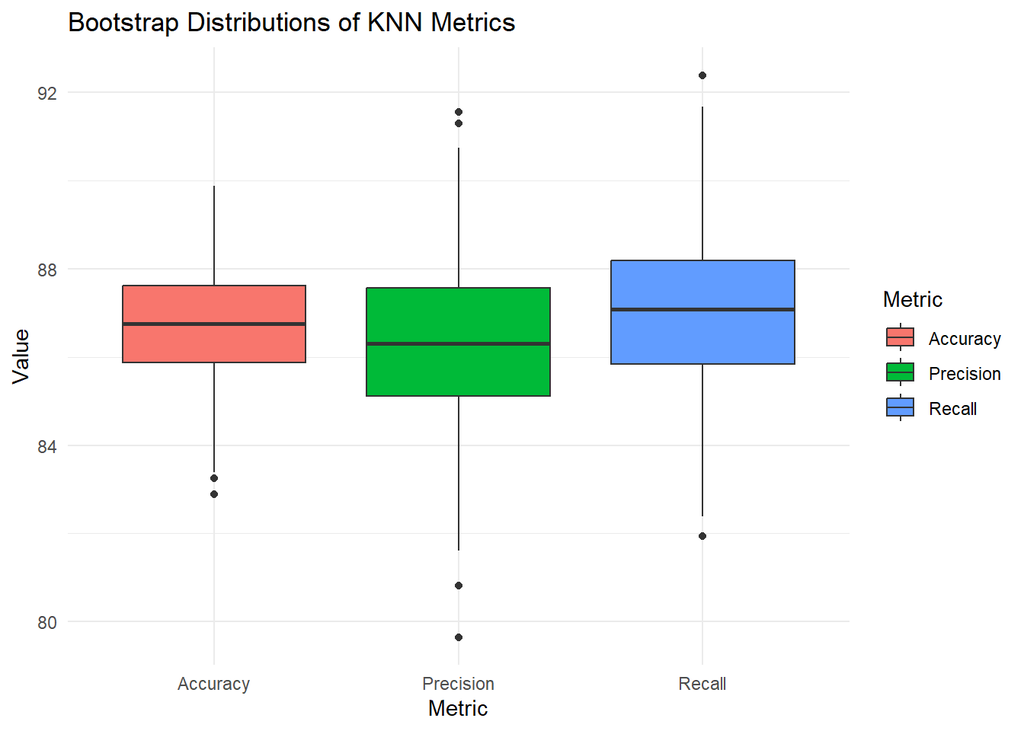

```r
set.seed(1)
# Combine results into a dataframe
results <- data.frame(
  Metric = rep(c("Accuracy", "Recall", "Precision"), each = iterations),
  Value = c(accuracy_knn, recall_knn, precision_knn))

# Boxplot
ggplot(results, aes(x = Metric, y = Value, fill = Metric)) +
  geom_boxplot() +
  labs(title = "Bootstrap Distributions of KNN Metrics",
       y = "Value") +
  theme_minimal()
```

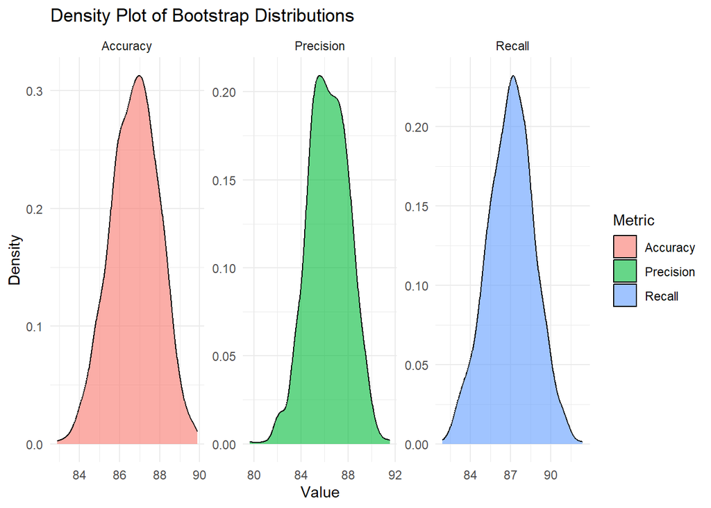

```r
# Density Plot
ggplot(results, aes(x = Value, fill = Metric)) +
  geom_density(alpha = 0.6) +
  facet_wrap(~Metric, scales = "free") +
  labs(title = "Density Plot of Bootstrap Distributions",
       x = "Value",
       y = "Density") +
  theme_minimal()
```